# 4. Exploratory Data Analysis

**탐색적 데이터 분석을 통해 데이터를 통달해봅시다.** with [Titanic Data](https://www.kaggle.com/c/titanic)

1. 라이브러리 준비
2. 분석의 목적과 변수 확인
3. 데이터 전체적으로 살펴보기
4. 데이터의 개별 속성 파악하기

## 0. 라이브러리 준비

```python
import numpy as np
import pandas as pd
import matplotlib.pyplot as plt
import seaborn as sns

%matplotlib inline
```

```python
## 동일 경로에 train.csv 존재

titanic_df = pd.read_csv("./titanic_train.csv")
```

## 1. 분석의 목적과 변수 확인

- 타이타닉 호에서 생존한 생존자들을 어떤 사람들인가??

```python
## 상위 5개 데이터 확인

titanic_df.head()
```

|  | PassengerId | Survived | Pclass | Name | Sex | Age | SibSp | Parch | Ticket | Fare | Cabin | Embarked |
| --- | --- | --- | --- | --- | --- | --- | --- | --- | --- | --- | --- | --- |
| 0 | 1 | 0 | 3 | Braund, Mr. Owen Harris | male | 22.0 | 1 | 0 | A/5 21171 | 7.2500 | NaN | S |
| 1 | 2 | 1 | 1 | Cumings, Mrs. John Bradley (Florence Briggs Th... | female | 38.0 | 1 | 0 | PC 17599 | 71.2833 | C85 | C |
| 2 | 3 | 1 | 3 | Heikkinen, Miss. Laina | female | 26.0 | 0 | 0 | STON/O2. 3101282 | 7.9250 | NaN | S |
| 3 | 4 | 1 | 1 | Futrelle, Mrs. Jacques Heath (Lily May Peel) | female | 35.0 | 1 | 0 | 113803 | 53.1000 | C123 | S |
| 4 | 5 | 0 | 3 | Allen, Mr. William Henry | male | 35.0 | 0 | 0 | 373450 | 8.0500 | NaN | S |

```python
## 각 column의 데이터 타입 확인

titanic_df.dtypes
```

```
PassengerId      int64
Survived         int64
Pclass           int64
Name            object
Sex             object
Age            float64
SibSp            int64
Parch            int64
Ticket          object
Fare           float64
Cabin           object
Embarked        object
dtype: object
```

## 2. 데이터 전체적으로 살펴보기

```python
## 데이터 전체 정보를 얻는 함수: .describe()

titanic_df.describe() # 수치형 데이터에 대한 요약만 제공!!
```

|  | PassengerId | Survived | Pclass | Age | SibSp | Parch | Fare |
| --- | --- | --- | --- | --- | --- | --- | --- |
| count | 891.000000 | 891.000000 | 891.000000 | 714.000000 | 891.000000 | 891.000000 | 891.000000 |
| mean | 446.000000 | 0.383838 | 2.308642 | 29.699118 | 0.523008 | 0.381594 | 32.204208 |
| std | 257.353842 | 0.486592 | 0.836071 | 14.526497 | 1.102743 | 0.806057 | 49.693429 |
| min | 1.000000 | 0.000000 | 1.000000 | 0.420000 | 0.000000 | 0.000000 | 0.000000 |
| 25% | 223.500000 | 0.000000 | 2.000000 | 20.125000 | 0.000000 | 0.000000 | 7.910400 |
| 50% | 446.000000 | 0.000000 | 3.000000 | 28.000000 | 0.000000 | 0.000000 | 14.454200 |
| 75% | 668.500000 | 1.000000 | 3.000000 | 38.000000 | 1.000000 | 0.000000 | 31.000000 |
| max | 891.000000 | 1.000000 | 3.000000 | 80.000000 | 8.000000 | 6.000000 | 512.329200 |

```python
## 상관계수 확인

titanic_df.corr()
# Correlation is NOT Causation
# 상관성: A up, B up -> 경향성을 나타냄
# 인과성: A -> B. 즉, 종속성을 나타냄
```

|  | PassengerId | Survived | Pclass | Age | SibSp | Parch | Fare |
| --- | --- | --- | --- | --- | --- | --- | --- |
| PassengerId | 1.000000 | -0.005007 | -0.035144 | 0.036847 | -0.057527 | -0.001652 | 0.012658 |
| Survived | -0.005007 | 1.000000 | -0.338481 | -0.077221 | -0.035322 | 0.081629 | 0.257307 |
| Pclass | -0.035144 | -0.338481 | 1.000000 | -0.369226 | 0.083081 | 0.018443 | -0.549500 |
| Age | 0.036847 | -0.077221 | -0.369226 | 1.000000 | -0.308247 | -0.189119 | 0.096067 |
| SibSp | -0.057527 | -0.035322 | 0.083081 | -0.308247 | 1.000000 | 0.414838 | 0.159651 |
| Parch | -0.001652 | 0.081629 | 0.018443 | -0.189119 | 0.414838 | 1.000000 | 0.216225 |
| Fare | 0.012658 | 0.257307 | -0.549500 | 0.096067 | 0.159651 | 0.216225 | 1.000000 |

```python
## 결측치 확인

titanic_df.isnull().sum()
# 나중에 상황에 따라 결측치가 있는 column 처리해야 한다!!
```

```
PassengerId      0
Survived         0
Pclass           0
Name             0
Sex              0
Age            177
SibSp            0
Parch            0
Ticket           0
Fare             0
Cabin          687
Embarked         2
dtype: int64
```

## 3. 데이터의 개별 속성 파악하기

### 1) Survived Column

```python
## 생존자, 사망자 명수는?

titanic_df['Survived'].value_counts()
# 0: 사망, 1: 생존자
```

```
0    549
1    342
Name: Survived, dtype: int64
```

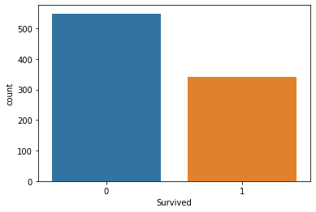

```python
## 생존자 수와 사망자 수를 Barplot으로 그리기 -> sns.countplot()

sns.countplot(x='Survived', data=titanic_df)
plt.show()
```

### 2) Pclass

```python
# Pclass에 따른 인원 파악

# Pclass에 따른 인원 수
titanic_df[['Pclass','Survived']].groupby(['Pclass']).count()
```

| Pclass | Survived |
| --- | --- |
| 1 | 216 |
| 2 | 184 |
| 3 | 491 |

```python
# 생존자 인원

# Pclass 별 생존자 인원 수(1의 개수)
titanic_df[['Pclass','Survived']].groupby(['Pclass']).sum()
```

| Pclass | Survived |
| --- | --- |
| 1 | 136 |
| 2 | 87 |
| 3 | 119 |

```python
# 생존 비율

# sum()한 것을 count()한 것으로 나눈 것이 mean()
titanic_df[['Pclass','Survived']].groupby(['Pclass']).mean()
```

| Pclass | Survived |
| --- | --- |
| 1 | 0.629630 |
| 2 | 0.472826 |
| 3 | 0.242363 |

```
[]
```

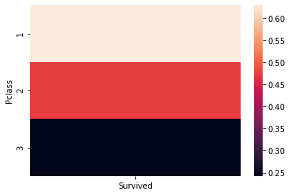

```python
sns.heatmap(titanic_df[['Pclass','Survived']].groupby(['Pclass']).mean())
plt.plot()
```

### 3) Sex

```python
titanic_df.groupby(['Survived','Sex'])['Survived'].count()
```

```
Survived  Sex
0         female     81
          male      468
1         female    233
          male      109
Name: Survived, dtype: int64
```

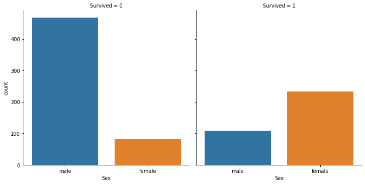

```python
sns.catplot(x='Sex', col='Survived', kind='count', data=titanic_df)
plt.show()
```

### 4) Age

**이 column은 결측치 존재!!**

```python
titanic_df.describe()['Age']
```

```
count    714.000000
mean      29.699118
std       14.526497
min        0.420000
25%       20.125000
50%       28.000000
75%       38.000000
max       80.000000
Name: Age, dtype: float64
```

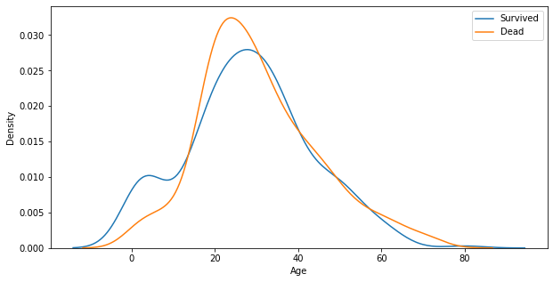

```python
## Survived 1, 0과 Age의 경향성

fig, ax = plt.subplots(1,1,figsize=(10,5))
sns.kdeplot(x=titanic_df[titanic_df.Survived==1]['Age'], ax=ax)
sns.kdeplot(x=titanic_df[titanic_df.Survived==0]['Age'], ax=ax)

plt.legend(['Survived', 'Dead'])
plt.show()

# 어린 아이들의 경우 Survived 비율이 높음
# 청년층 (20대 ~ 30대)와 고령층 (60대 ~ 80대)의 경우 사망 비율이 높음
```

### Appendix 1) Sex + Pclass vs Survived

- 복합적인 요소에 대한 분석

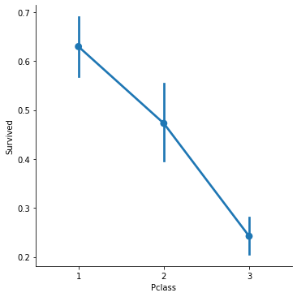

```python
sns.catplot(x='Pclass',y='Survived', kind='point', data=titanic_df)
plt.show()
```

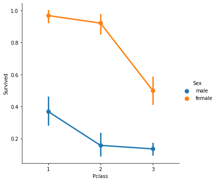

```python
sns.catplot(x='Pclass',y='Survived', hue='Sex', kind='point', data=titanic_df)
# hue: 다른 범주형으로 그래프를 나누도록 한다.
plt.show()

# 막대: 신뢰 구간
# 더 높은 등급에 탑승할수록 생존할 가능성이 크다
```

### Appendix 2) Age + Pclass

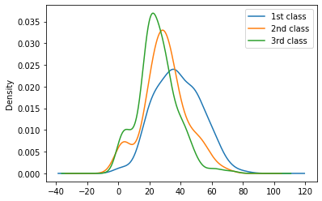

```python
## Age graph with Pclass

titanic_df['Age'][titanic_df.Pclass == 1].plot(kind = 'kde')
titanic_df['Age'][titanic_df.Pclass == 2].plot(kind = 'kde')
titanic_df['Age'][titanic_df.Pclass == 3].plot(kind = 'kde')

plt.legend(['1st class','2nd class','3rd class'])
plt.show()

# 더 높은 class일수록 나이대가 높다.
```

## Mission : It's Your Turn!

### 1. 본문에서 언급된 Feature를 제외하고 유의미한 Feature를 1개 이상 찾아봅시다.

- Hint : Fare? Sibsp? Parch?
- 본문에서 유의미한 feature: Pclass, Sex 등

```python
# Fare에 따른 생존 분석

titanic_df.groupby(['Survived','Fare'])['Survived'].count()
```

```
Survived  Fare
0         0.0000      14
          4.0125       1
          5.0000       1
          6.2375       1
          6.4375       1
                      ..
1         227.5250     3
          247.5208     1
          262.3750     2
          263.0000     2
          512.3292     3
Name: Survived, Length: 330, dtype: int64
```

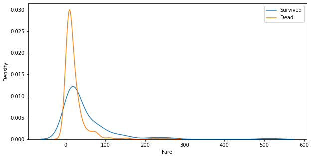

```python
fig, ax = plt.subplots(1,1,figsize=(10,5))
sns.kdeplot(x=titanic_df[titanic_df.Survived==1]['Fare'], ax=ax)
sns.kdeplot(x=titanic_df[titanic_df.Survived==0]['Fare'], ax=ax)

plt.legend(['Survived', 'Dead'])
plt.show()
```

전체적으로 요금을 비싸게 냈던 사람들의 경우 싸게 냈던 사람들(0 부근의 fare)보다 생존을 조금 더 많이 하는 것을 확인 반대로 요금을 싸게 냈던 사람들의 경우 비싸게 냈던 사람들 보다 사망을 많이 한 것을 확인

### 2. [Kaggle](https://www.kaggle.com/datasets)에서 Dataset(Titanic 제외)을 찾고, 이 Dataset에서 유의미한 Feature를 3개 이상 찾고 이를 시각화해봅시다.

함께 보면 좋은 라이브러리 document

- numpy
- pandas
- seaborn
- matplotlib

### Hint

1. 데이터 톺아보기
   - 각 데이터는 어떤 자료형?
   - 데이터 결측치 유무
   - 데이터의 자료형을 바꿔야 하나?
2. 데이터에 대한 가설
   - 가설은 개인의 경험에 의해서 도출 가능
   - 가설은 명확할 수록 좋다
3. 가설을 검증하기 위한 증거 찾기
   - 여러 기술을 써야한다.
   - groupby()를 통해서 그룹화된 정보에 통계량을 도입해보기
   - .merge()를 통해 두개 이상의 dataframe을 합쳐보기
   - 시각화를 통해 일목요연하게 보여주기

```python
# 한국 코로나 데이터셋 불러오기
import pandas as pd
import seaborn as sns
import matplotlib.pyplot as plt
corona = pd.read_csv('./case.csv')

corona
```

|  | case_id | province | city | group | infection_case | confirmed | latitude | longitude |
| --- | --- | --- | --- | --- | --- | --- | --- | --- |
| 0 | 1 | Seoul | Guro-gu | True | Guro-gu Call Center | 70 | 37.508163 | 126.884387 |
| 1 | 2 | Seoul | Eunpyeong-gu | True | Eunpyeong St. Mary's Hospital | 14 | 37.63369 | 126.9165 |
| 2 | 3 | Seoul | Seongdong-gu | True | Seongdong-gu APT | 13 | 37.55713 | 127.0403 |
| 3 | 4 | Seoul | Jongno-gu | True | Jongno Community Center | 10 | 37.57681 | 127.006 |
| 4 | 5 | Seoul | Dongdaemun-gu | True | Dongan Church | 9 | 37.592888 | 127.056766 |
| ... | ... | ... | ... | ... | ... | ... | ... | ... |
| 73 | 74 | Gyeongsangnam-do | Changwon-si | True | Hanmaeum Changwon Hospital | 7 | 35.22115 | 128.6866 |
| 74 | 75 | Gyeongsangnam-do | Changnyeong-gun | True | Changnyeong Coin Karaoke | 7 | 35.54127 | 128.5008 |
| 75 | 76 | Gyeongsangnam-do | from other city | True | Onchun Church | 2 | - | - |
| 76 | 77 | Gyeongsangnam-do | - | False | etc | 22 | - | - |
| 77 | 78 | Jeju-do | - | False | etc | 4 | - | - |

78 rows × 8 columns

```python
# 개인으로 많이 감염되었는지 아니면 집단에서 많이 감염되었는지 확인
corona_group = corona[['confirmed', 'group']]

corona_group
```

|  | confirmed | group |
| --- | --- | --- |
| 0 | 70 | True |
| 1 | 14 | True |
| 2 | 13 | True |
| 3 | 10 | True |
| 4 | 9 | True |
| ... | ... | ... |
| 73 | 7 | True |
| 74 | 7 | True |
| 75 | 2 | True |
| 76 | 22 | False |
| 77 | 4 | False |

78 rows × 2 columns

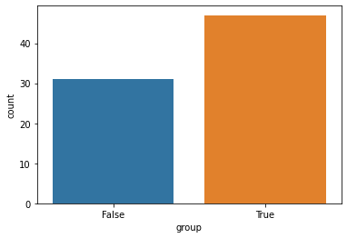

```python
sns.countplot(x='group', data=corona_group)
plt.show()

# 집단인 case_id가 더 많음
```

```python
# 어느 province에서 확진자가 많이 발생했는지 확인
corona_prov = corona[['province', 'confirmed']].groupby(['province']).sum()

corona_prov

# 대구가 압도적으로 많은 것을 한 번에 볼 수 있음
# 이 때 한창 코로나 초기 때 신천지로 인한 대량 감염인 것으로 추정
```

| province | confirmed |
| --- | --- |
| Busan | 90 |
| Chungcheongbuk-do | 27 |
| Chungcheongnam-do | 114 |
| Daegu | 5867 |
| Daejeon | 20 |
| Gangwon-do | 29 |
| Gwangju | 15 |
| Gyeonggi-do | 113 |
| Gyeongsangbuk-do | 1125 |
| Gyeongsangnam-do | 85 |
| Incheon | 25 |
| Jeju-do | 4 |
| Jeollabuk-do | 7 |
| Jeollanam-do | 4 |
| Sejong | 19 |
| Seoul | 175 |
| Ulsan | 25 |

```python
# 정말 대구의 경우 대부분 신천지에서 많이 감염된 것인지 확인
# corona_Daegu = corona[corona['province'] == 'Daegu']
corona_Daegu = corona[corona['province'] == 'Daegu'][['confirmed', 'infection_case']]
corona_Daegu

# 한 번에 봐도 신천지에서 많이 감염된 것을 확인
```

|  | confirmed | infection_case |
| --- | --- | --- |
| 15 | 4126 | Shincheonji Church |
| 16 | 680 | contact with patient |
| 17 | 2 | Cheongdo Daenam Hospital |
| 18 | 1059 | etc |